# Assignment2

Author

Vanessa Ramos

## DATA WRANGLING

```r
library(tidytext)
library(readr)
library(dplyr)
library(ggplot2)
library(tidyr)
library(leaflet)
library(data.table)
```

```r
individual <- read_csv("https://raw.githubusercontent.com/USCbiostats/data-science-data/master/01_chs/chs_individual.csv")
```

```r
regional <- read_csv("https://raw.githubusercontent.com/USCbiostats/data-science-data/master/01_chs/chs_regional.csv")
```

Used str(regional) and str(individual) to look at the variable types

Part 1

```r
newdata <- merge(
  # Data
  x     = individual,
  y     = regional,
  # List of variables to match
  by.x  = "townname",
  by.y  = "townname",
  # Which obs to keep?
  all.x = TRUE,
  all.y = TRUE
  )
```

```r
#str(newdata)
#viewing dataset structure and variable types
```

Part 2

```r
newdata <- mutate(newdata, obesity_level= ifelse(bmi<=14,
"underweight", ifelse(bmi > 14 & bmi < 22,"normal","overweight")))
```

**used chatgpt to figure out how to use the & symbol

**used chatgpt to figrue out how to use the & symbol and the second ifelse

```r
library(vtable)
st(newdata, group = 'obesity_level', group.test = TRUE)
```

Summary Statistics

| obesity_level Variable | normal N | normal Mean | normal SD | overweight N | overweight Mean | overweight SD | underweight N | underweight Mean | underweight SD | Test |
| --- | --- | --- | --- | --- | --- | --- | --- | --- | --- | --- |
| sid | 886 | 1033 | 591 | 190 | 1045 | 595 | 35 | 1002 | 592 | F=0.081<sup></sup> |
| male | 886 | 0.49 | 0.5 | 190 | 0.58 | 0.5 | 35 | 0.34 | 0.48 | F=4.434<sup>**</sup> |
| race | 886 |  |  | 190 |  |  | 35 |  |  | X2=21.828<sup>**</sup> |
| ... A | 42 | 5% |  | 4 | 2% |  | 4 | 11% |  |  |
| ... B | 38 | 4% |  | 10 | 5% |  | 1 | 3% |  |  |
| ... D | 8 | 1% |  | 3 | 2% |  | 1 | 3% |  |  |
| ... M | 98 | 11% |  | 27 | 14% |  | 5 | 14% |  |  |
| ... O | 193 | 22% |  | 60 | 32% |  | 5 | 14% |  |  |
| ... W | 507 | 57% |  | 86 | 45% |  | 19 | 54% |  |  |
| hispanic | 886 | 0.41 | 0.49 | 190 | 0.55 | 0.5 | 35 | 0.46 | 0.51 | F=6.374<sup>***</sup> |
| agepft | 886 | 9.9 | 0.43 | 190 | 9.9 | 0.44 | 35 | 9.9 | 0.43 | F=0.482<sup></sup> |
| height | 886 | 138 | 6.3 | 190 | 143 | 7 | 35 | 133 | 6.3 | F=61.804<sup>***</sup> |
| weight | 886 | 73 | 12 | 190 | 114 | 19 | 35 | 52 | 6 | F=848.062<sup>***</sup> |
| bmi | 886 | 17 | 2 | 190 | 25 | 3.1 | 35 | 13 | 0.61 | F=1114.837<sup>***</sup> |
| asthma | 865 | 0.14 | 0.35 | 185 | 0.19 | 0.39 | 35 | 0.086 | 0.28 | F=1.955<sup></sup> |
| active_asthma | 886 | 0.18 | 0.38 | 190 | 0.27 | 0.45 | 35 | 0.14 | 0.36 | F=5.121<sup>***</sup> |
| father_asthma | 811 | 0.074 | 0.26 | 179 | 0.1 | 0.3 | 29 | 0.14 | 0.35 | F=1.365<sup></sup> |
| mother_asthma | 846 | 0.09 | 0.29 | 184 | 0.14 | 0.34 | 34 | 0.088 | 0.29 | F=1.835<sup></sup> |
| wheeze | 831 | 0.33 | 0.47 | 184 | 0.37 | 0.48 | 33 | 0.3 | 0.47 | F=0.59<sup></sup> |
| hayfever | 798 | 0.18 | 0.38 | 174 | 0.16 | 0.37 | 33 | 0.3 | 0.47 | F=1.942<sup></sup> |
| allergy | 842 | 0.29 | 0.45 | 180 | 0.29 | 0.45 | 34 | 0.32 | 0.47 | F=0.088<sup></sup> |
| educ_parent | 845 | 2.9 | 1.1 | 175 | 2.6 | 1.1 | 34 | 2.8 | 1.1 | F=3.793<sup>**</sup> |
| smoke | 857 | 0.15 | 0.36 | 184 | 0.18 | 0.39 | 35 | 0.11 | 0.32 | F=0.869<sup></sup> |
| pets | 886 | 0.79 | 0.41 | 190 | 0.72 | 0.45 | 35 | 0.63 | 0.49 | F=4.411<sup>**</sup> |
| gasstove | 867 | 0.78 | 0.41 | 183 | 0.8 | 0.4 | 34 | 0.85 | 0.36 | F=0.625<sup></sup> |
| fev | 882 | 1998 | 309 | 189 | 2249 | 322 | 34 | 1687 | 300 | F=71.929<sup>***</sup> |
| fvc | 881 | 2277 | 362 | 188 | 2623 | 400 | 34 | 1886 | 333 | F=93.288<sup>***</sup> |
| mmef | 873 | 2378 | 582 | 187 | 2534 | 584 | 34 | 2201 | 657 | F=7.519<sup>***</sup> |
| pm25_mass | 886 | 15 | 7.8 | 190 | 14 | 7.6 | 35 | 15 | 7.6 | F=1.222<sup></sup> |
| pm25_so4 | 886 | 1.9 | 0.79 | 190 | 1.8 | 0.8 | 35 | 2 | 0.84 | F=0.375<sup></sup> |
| pm25_no3 | 886 | 4.6 | 3.6 | 190 | 4.1 | 3.5 | 35 | 4.8 | 3.6 | F=1.254<sup></sup> |
| pm25_nh4 | 886 | 1.8 | 1.2 | 190 | 1.6 | 1.2 | 35 | 1.9 | 1.2 | F=1.277<sup></sup> |
| pm25_oc | 886 | 4.6 | 2.7 | 190 | 4.3 | 2.6 | 35 | 4.7 | 2.6 | F=0.832<sup></sup> |
| pm25_ec | 886 | 0.75 | 0.4 | 190 | 0.71 | 0.41 | 35 | 0.78 | 0.42 | F=0.879<sup></sup> |
| pm25_om | 886 | 5.5 | 3.2 | 190 | 5.2 | 3.1 | 35 | 5.6 | 3.2 | F=0.834<sup></sup> |
| pm10_oc | 886 | 5.9 | 3.4 | 190 | 5.6 | 3.3 | 35 | 6 | 3.4 | F=0.833<sup></sup> |
| pm10_ec | 886 | 0.76 | 0.41 | 190 | 0.72 | 0.42 | 35 | 0.8 | 0.42 | F=0.882<sup></sup> |
| pm10_tc | 886 | 6.9 | 3.8 | 190 | 6.5 | 3.7 | 35 | 7.1 | 3.8 | F=0.861<sup></sup> |
| formic | 886 | 1.4 | 0.79 | 190 | 1.2 | 0.74 | 35 | 1.3 | 0.7 | F=1.929<sup></sup> |
| acetic | 886 | 3.1 | 1.3 | 190 | 2.8 | 1.3 | 35 | 3.1 | 1.2 | F=2.824<sup>*</sup> |
| hcl | 886 | 0.42 | 0.13 | 190 | 0.43 | 0.14 | 35 | 0.43 | 0.16 | F=0.242<sup></sup> |
| hno3 | 886 | 2.4 | 1.2 | 190 | 2.2 | 1.2 | 35 | 2.5 | 1 | F=2.752<sup>*</sup> |
| o3_max | 886 | 61 | 14 | 190 | 58 | 14 | 35 | 62 | 15 | F=3.504<sup>**</sup> |
| o3106 | 886 | 48 | 11 | 190 | 46 | 11 | 35 | 49 | 12 | F=2.65<sup>*</sup> |
| o3_24 | 886 | 30 | 10 | 190 | 30 | 9.6 | 35 | 32 | 11 | F=0.708<sup></sup> |
| no2 | 886 | 19 | 11 | 190 | 18 | 10 | 35 | 19 | 10 | F=0.877<sup></sup> |
| pm10 | 886 | 33 | 14 | 190 | 32 | 14 | 35 | 34 | 14 | F=0.811<sup></sup> |
| no_24hr | 811 | 16 | 13 | 178 | 16 | 14 | 31 | 19 | 14 | F=0.492<sup></sup> |
| pm2_5_fr | 672 | 20 | 8.5 | 139 | 19 | 8.3 | 26 | 21 | 8 | F=1.118<sup></sup> |
| iacid | 886 | 2.8 | 1.3 | 190 | 2.6 | 1.3 | 35 | 2.9 | 1.1 | F=2.373<sup>*</sup> |
| oacid | 886 | 4.4 | 2 | 190 | 4.1 | 2 | 35 | 4.5 | 1.8 | F=2.6<sup>*</sup> |
| total_acids | 886 | 6.8 | 3.2 | 190 | 6.3 | 3.1 | 35 | 7 | 2.8 | F=2.691<sup>*</sup> |
| lon | 886 | -118 | 1.3 | 190 | -118 | 1.4 | 35 | -118 | 1 | F=2.729<sup>*</sup> |
| lat | 886 | 34 | 0.66 | 190 | 34 | 0.68 | 35 | 34 | 0.47 | F=0.849<sup></sup> |

Statistical significance markers: * p<0.1; ** p<0.05; *** p<0.01

**the above table was not asked for, but I wanted to save it for future use (thought it was interesting)**

```r
table <- newdata %>%
  group_by(obesity_level) %>%
  summarize( min(bmi), max(bmi), total=n())
table
```

```
# A tibble: 4 × 4
  obesity_level `min(bmi)` `max(bmi)` total
  <chr>              <dbl>      <dbl> <int>
1 normal              14.0       22.0   886
2 overweight          22.0       41.3   190
3 underweight         11.3       14.0    35
4 <NA>                NA         NA      89
```

**used chatgpt for n() and min/max format part

Part 3: creating smoke_gas_exposure variable

```r
newdata <- mutate(newdata, smoke_gas_exposure= ifelse(smoke==1 & gasstove==1, "sygy", ifelse(smoke==0 & gasstove==1, "sngy", ifelse(smoke==1 & gasstove==0, "sygn", "sngn"))))

                                                                         #sygy:smoke yes & gasstove yes
#sngy: smoke no & gasstove yes
#sygn: smoke yes & gasstove no
#sngn: smoke no & gasstove no
```

Part 4: Summary tables of avg and sd FEV and asthma by town, sex, obesity level, and smoke_gas_exposure

```r
newdata %>%
  filter(townname!= "NA") %>%
  filter(asthma != "NA") %>%
  filter(fev != "NA") %>%
  group_by(townname) %>%
  summarize(mean(asthma), sd(asthma), mean(fev), sd(fev))
```

```
# A tibble: 12 × 5
   townname      `mean(asthma)` `sd(asthma)` `mean(fev)` `sd(fev)`
   <chr>                  <dbl>        <dbl>       <dbl>     <dbl>
 1 Alpine                 0.120        0.326       2093.      301.
 2 Atascadero             0.258        0.440       2080.      334.
 3 Lake Elsinore          0.126        0.334       2039.      323.
 4 Lake Gregory           0.157        0.366       2092.      338.
 5 Lancaster              0.153        0.362       2003.      339.
 6 Lompoc                 0.125        0.333       2043.      372.
 7 Long Beach             0.144        0.354       1980.      332.
 8 Mira Loma              0.170        0.378       1992.      335.
 9 Riverside              0.110        0.314       1986.      290.
10 San Dimas              0.165        0.373       2032.      320.
11 Santa Maria            0.125        0.333       2020.      331.
12 Upland                 0.110        0.314       2030.      358.
```

```r
newdata %>%
  filter(male!= "NA") %>%
  filter(asthma != "NA") %>%
  filter(fev != "NA") %>%
  group_by(male) %>%
  summarize(mean(asthma), sd(asthma), mean(fev), sd(fev))
```

```
# A tibble: 2 × 5
   male `mean(asthma)` `sd(asthma)` `mean(fev)` `sd(fev)`
  <dbl>          <dbl>        <dbl>       <dbl>     <dbl>
1     0          0.118        0.323       1958.      329.
2     1          0.177        0.382       2108.      318.
```

```r
newdata %>%
  filter(obesity_level!= "NA") %>%
  filter(asthma != "NA") %>%
    filter(fev != "NA") %>%
  group_by(obesity_level) %>%
  summarize(mean(asthma), sd(asthma), mean(fev), sd(fev))
```

```
# A tibble: 3 × 5
  obesity_level `mean(asthma)` `sd(asthma)` `mean(fev)` `sd(fev)`
  <chr>                  <dbl>        <dbl>       <dbl>     <dbl>
1 normal                0.141         0.348       1999.      310.
2 overweight            0.190         0.394       2256.      321.
3 underweight           0.0882        0.288       1687.      300.
```

```r
newdata %>%
  filter(smoke_gas_exposure!= "NA") %>%
  filter(asthma != "NA") %>%
  filter(fev != "NA") %>%
  group_by(smoke_gas_exposure) %>%
  summarize(mean(asthma), sd(asthma), mean(fev), sd(fev))
```

```
# A tibble: 4 × 5
  smoke_gas_exposure `mean(asthma)` `sd(asthma)` `mean(fev)` `sd(fev)`
  <chr>                       <dbl>        <dbl>       <dbl>     <dbl>
1 sngn                        0.129        0.336       2060.      344.
2 sngy                        0.152        0.360       2027.      329.
3 sygn                        0.179        0.390       2064.      333.
4 sygy                        0.144        0.352       2014.      317.
```

## Looking at the Data (EDA)

Step 1: Formulate a question:

1. What is the association between BMI and FEV (forced expiratory volume)?
2. What is the association between smoke and gas exposure and FEV?
3. What is the association between PM2.5 exposure and FEV?

Step 2: Read in the data

Completed in prior steps

Step 3: Check the dimensions and headers and footers of the data

```r
dim(newdata)
```

```
[1] 1200   51
```

```r
#head(newdata)
```

```r
#tail(newdata)
```

Step 4: Check the variable types in the data

```r
#str(newdata)
```

Step 5: Take a closer look at some of the variables

In this case, main variables are: smoke, gasstove, fev, bmi/obesity_level

```r
table(newdata$smoke)
```

```
  0   1
970 190
```

```r
table(newdata$gasstove)
```

```
  0   1
255 912
```

```r
table(newdata$obesity_level)
```

```
     normal  overweight underweight
        886         190          35
```

```r
summary(newdata$bmi)
```

```
   Min. 1st Qu.  Median    Mean 3rd Qu.    Max.    NA's
  11.30   15.78   17.48   18.50   20.35   41.27      89
```

```r
summary(newdata$fev)
```

```
   Min. 1st Qu.  Median    Mean 3rd Qu.    Max.    NA's
  984.8  1809.0  2022.7  2031.3  2249.7  3323.7      95
```

bmi and fev have missing values…

```r
mean(is.na(newdata$fev))
```

```
[1] 0.07916667
```

```r
mean(is.na(newdata$bmi))
```

```
[1] 0.07416667
```

7.9% of the data are missing in fev, and 7.4% are missing in bmi.

```r
newnewdata <- filter(newdata, smoke==1) %>%
 select(bmi, obesity_level, asthma, pm25_mass)
```

Step 6: Validate with an external source

Based on the tables from step 4 of preparing the data, values of asthma and smoke gas exposure seem to reflect what we might assume (higher levels of pollution may lead to higher levels of asthma in children). Additionally, those with higher BMI seem to have higher fev, which also mirrors what we know about obesity and breathing.

Step 7: Conduct summary statistics to answer initial question

1. What is the association between BMI and FEV (forced expiratory volume)?

```r
newdata %>%
  filter(fev!= "NA") %>%
  filter(obesity_level != "NA") %>%
  group_by(obesity_level) %>%
  summarize(mean(fev), sd(fev))
```

```
# A tibble: 3 × 3
  obesity_level `mean(fev)` `sd(fev)`
  <chr>               <dbl>     <dbl>
1 normal              1998.      309.
2 overweight          2249.      322.
3 underweight         1687.      300.
```

2. What is the association between smoke and gas exposure and FEV?

```r
newdata %>%
  filter(smoke_gas_exposure!= "NA") %>%
  filter(fev != "NA") %>%
  group_by(smoke_gas_exposure) %>%
  summarize(mean(fev), sd(fev))
```

```
# A tibble: 4 × 3
  smoke_gas_exposure `mean(fev)` `sd(fev)`
  <chr>                    <dbl>     <dbl>
1 sngn                     2060.      343.
2 sngy                     2026.      328.
3 sygn                     2064.      333.
4 sygy                     2020.      313.
```

3. What is the association between PM2.5 exposure and FEV?

```r
newdata %>%
  filter(pm25_mass != "NA") %>%
 summarize(mean(pm25_mass))
```

```
  mean(pm25_mass)
1        14.36167
```

```r
newdata %>%
  filter(fev != "NA") %>%
 summarize(mean(fev))
```

```
  mean(fev)
1  2031.265
```

Step 8: Make exploratory graphs

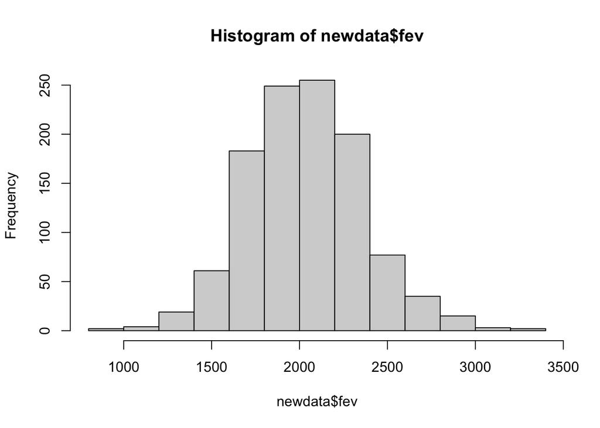

```r
#Association between BMI and FEV
hist(newdata$fev)
```

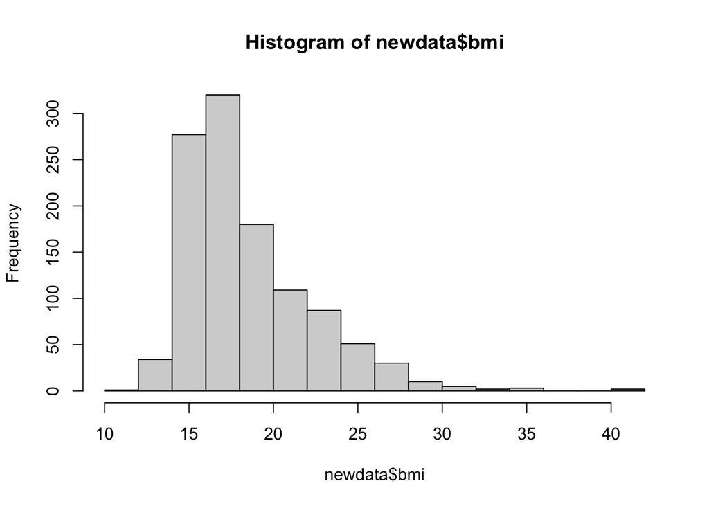

```r
hist(newdata$bmi)
```

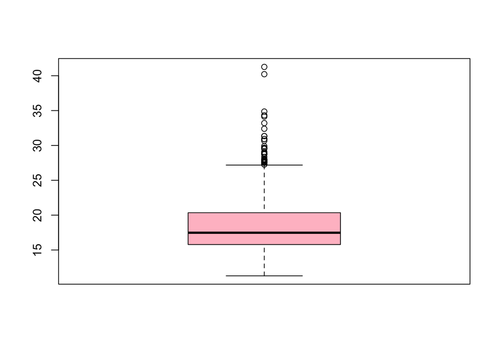

```r
boxplot(newdata$bmi, col="pink")
```

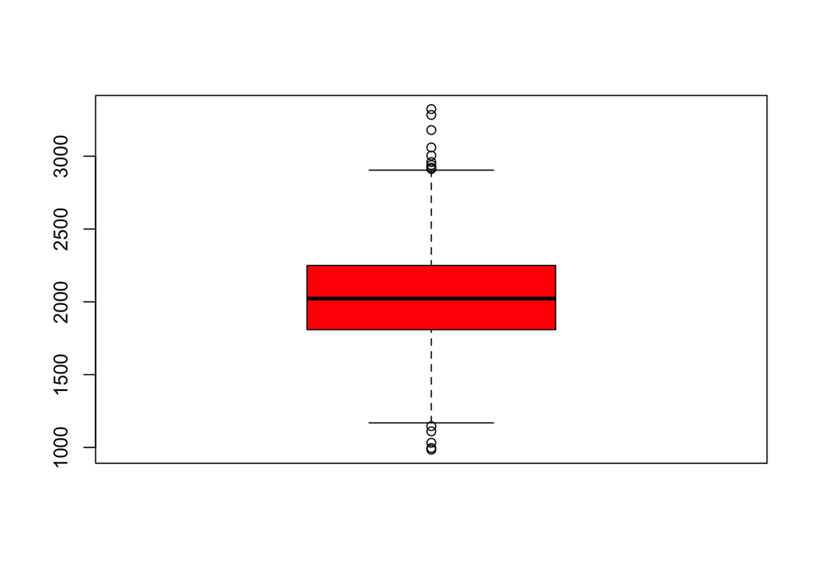

```r
boxplot(newdata$fev, col="red")
```

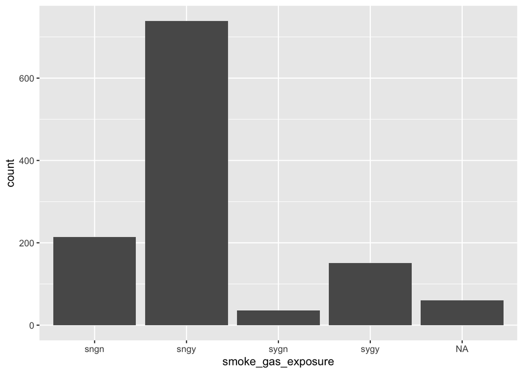

```r
#Association between smoke_gas_exposure and fev
library(ggplot2)

ggplot(data = newdata, aes(x = smoke_gas_exposure)) + geom_bar()
```

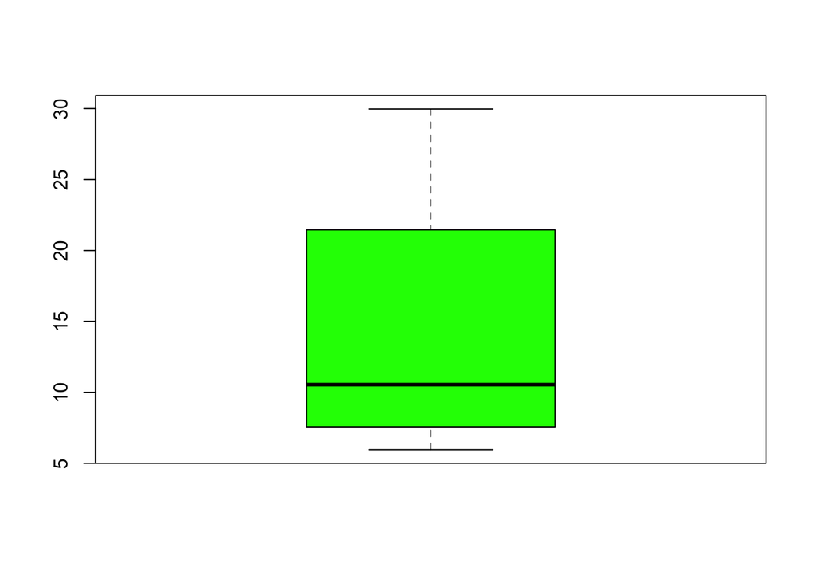

```r
#association between PM2.5 exposure and FEV
boxplot(newdata$pm25_mass, col="green")
```

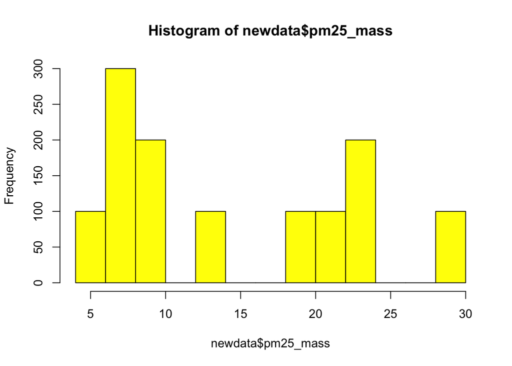

```r
hist(newdata$pm25_mass, col="yellow")
```

## Data Visualization

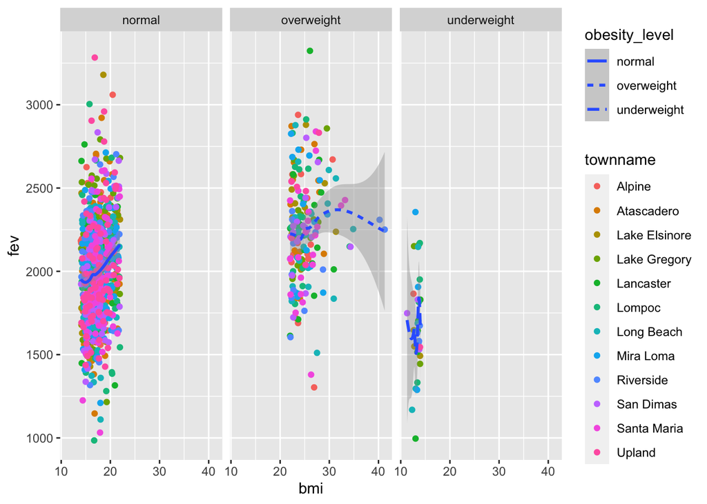

```r
#facet plot with scatterplot (with regression line) of BMI vs FEV by townname
plots <- filter(newdata, !is.na(fev) & !is.na(bmi) & !is.na(townname))
plots %>%
  ggplot() +
  geom_point(mapping = aes(x = bmi, y = fev, color=townname, position="jitter")) +
  geom_smooth(mapping = aes(x = bmi, y = fev, linetype = obesity_level)) +
  facet_wrap(~ obesity_level, nrow = 1)
```

It is hard to distinguish prominent patterns of towns in the graphs, as there are lots of overlapping data(even with the jitter option). However, based on first glance it seems that the more “pink” towns (San Dimas, Santa Maria, and Upland) have most of their values in the normal range of BMI’s. The underweight category has too few points to tell any noticeable patterns, and the overweight category seems to have an equal mix of towns.

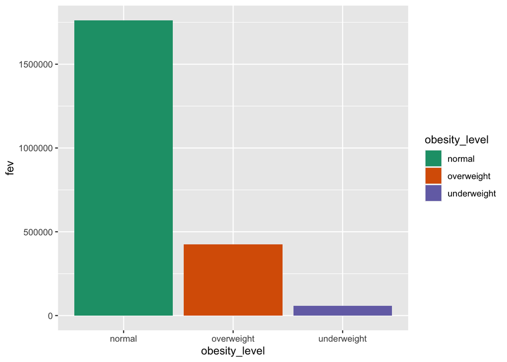

```r
#Stacked histograms of FEV by BMI category and FEV by smoke/gas exposure. Use different color schemes than the ggplot default.
ggplot(plots, aes(x=obesity_level, y= fev, fill =obesity_level)) +
     geom_bar(stat='identity') +
scale_fill_brewer(palette = "Dark2")
```

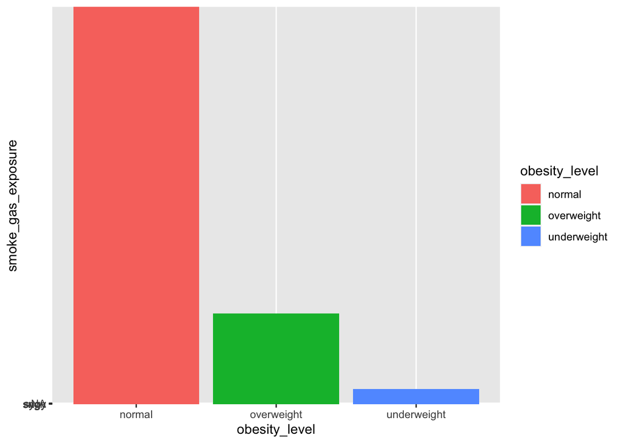

```r
#Barchart of BMI by smoke/gas exposure

ggplot(plots, aes(x=obesity_level, y= smoke_gas_exposure, fill= obesity_level)) +
     geom_bar(stat='identity')
```

Most of the data in the graphs falls under the normal weight category, meaning children with normal obesity levels have the highest counts of second hand smoke and gas stove emissions. Although there seems to be a large difference between normal and any other obesity level, further significant testing is required to make any official statement of association.

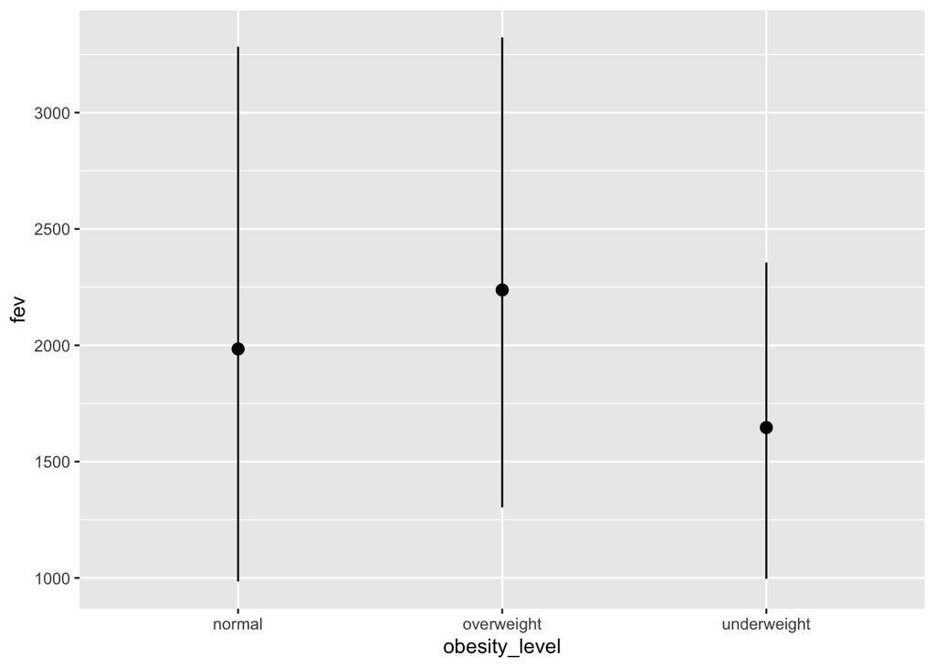

```r
#Statistical summary graphs of FEV by BMI and FEV by smoke/gas exposure category
l <- plots%>%
  ggplot() +
    stat_summary(mapping = aes(x = obesity_level, y = fev),
    fun.min = min,
    fun.max = max,
    fun = median)
l
```

There seems to be a difference between underweight vs. FEV compared to the other BMI categories, as it is lower than the other obesity levels. Additionally, it seems that the overweight BMI has on average, large FEV values than any other BMI category. However, this data may not be accurate to interpret because there seems to be much more children with a normal BMI, less children with an overweight BMI, and very few children with an underweight BMI. Further significance testing is required.

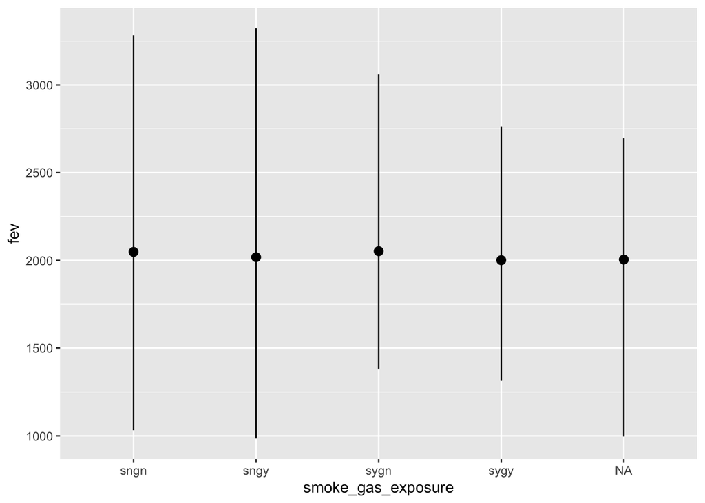

```r
m <- plots%>%
  ggplot() +
    stat_summary(mapping = aes(x = smoke_gas_exposure, y = fev),
    fun.min = min,
    fun.max = max,
    fun = median)
m
```

Based on the statistical summary graph, there does not seem to be much difference in FEV by smoke/gas exposure categories, as all centers seem to align with each other. However, just as with the graph above, further significance tests are required before making a definitive conclusion.

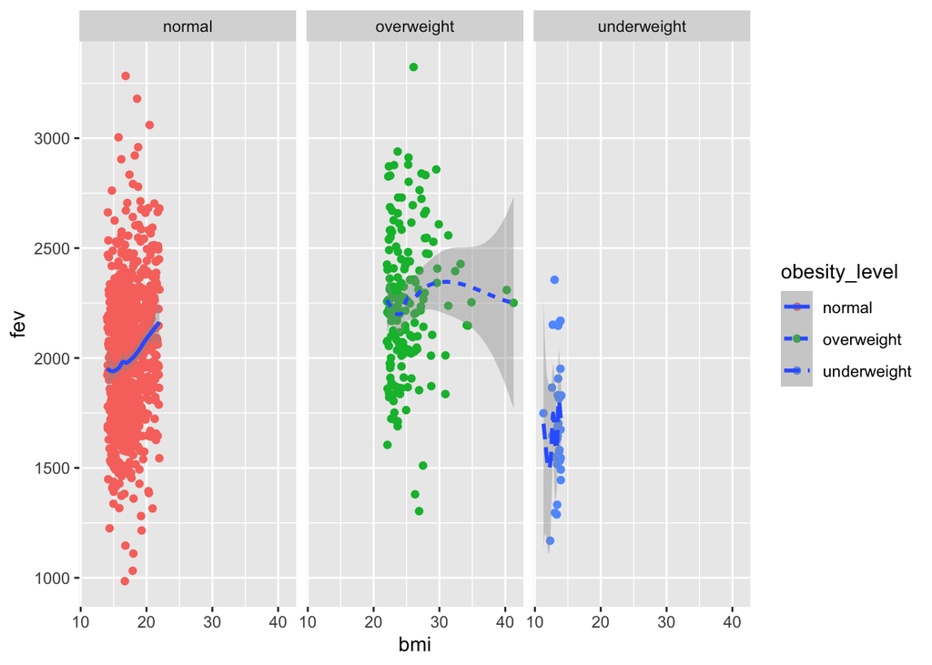

```r
plots <- filter(newdata, !is.na(fev) & !is.na(bmi) & !is.na(smoke_gas_exposure))
plots %>%
  ggplot() +
  geom_point(mapping = aes(x = bmi, y = fev, color=obesity_level, position="jitter")) +
  geom_smooth(mapping = aes(x = bmi, y = fev, linetype = obesity_level)) +
  facet_wrap(~ obesity_level, nrow = 1)
```

Graph above not asked (I wanted to create a facet wrap of the same question (fev by bmi) to get a different look at the data)

```r
#A leaflet map showing the concentrations of PM2.5 mass in each of the CHS communities

pm.pal <-colorNumeric(c('darkgreen','goldenrod','brown'), domain=plots$pm25_mass)

leafplot <- leaflet(plots) %>%
  # The looks of the Map
  addProviderTiles('CartoDB.Positron') %>%
  # Some circles
  addCircles(
    lat = ~lat, lng=~lon,
                                                  # HERE IS OUR PAL!
    label = ~paste0(round(pm25_mass)), color = ~ pm.pal(pm25_mass),
    opacity = 1, fillOpacity = 1
    ) %>%
  # And a pretty legend
  addLegend('bottomleft', pal=pm.pal, values=plots$pm25_mass,
          title='PM 2.5 Concentration in CHS Communities', opacity=1)
leafplot
```

[interactive chart not shown]

The map shows that the concentration levels of pm 2.5 mass are higher near a more largely populated and urban locations of Los Angeles. This makes sense given that pm 2.5 comes from heavy pollutant such as power plants, and car emissions. Locations with lower levels of pm 2.5 are less populated areas that are in more natural settings (in mountainous regions).

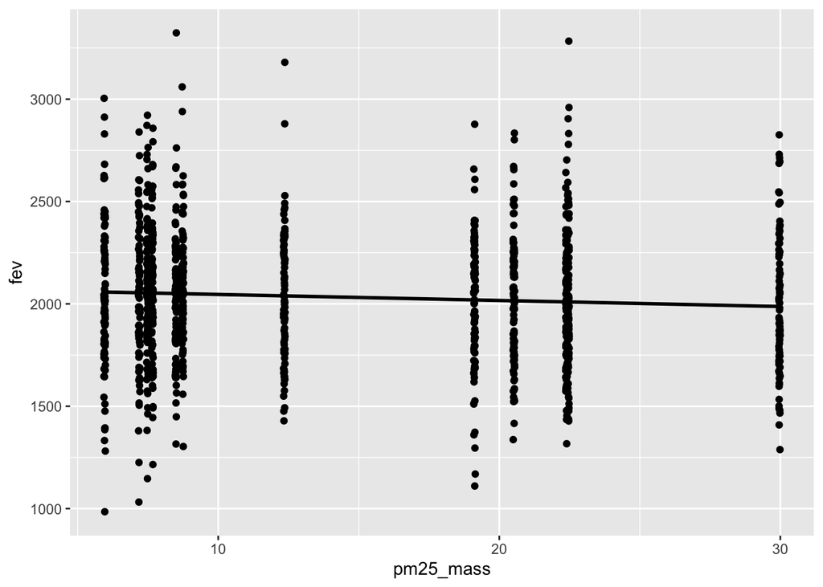

```r
#Choose a visualization to examine whether PM2.5 mass is associated with FEV
plots%>%
  ggplot(mapping = aes(x = pm25_mass, y = fev)) +
  geom_point( position="jitter") +
  geom_smooth(method = lm, se = FALSE, col = "black")
```

The linear regression line depicted above seems to denote that FEV slightly decreases as pm 2.5 increases. This line is not steep, and almost horizontal however. Although the pm25_mass variable was numeric, the graph above seems to show that its values are grouped within distinct numbers. Due to this, I have created a new categorical variable for pm2.5 mass levels, and will interpret its graph

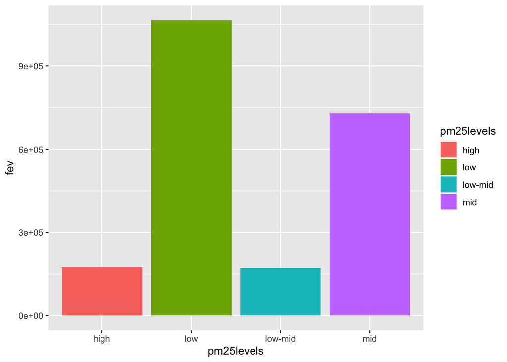

```r
plots <- mutate (plots, pm25levels = ifelse(pm25_mass < 10, "low",
                                            ifelse(pm25_mass>10 & pm25_mass<15, "low-mid",
                                                   ifelse(pm25_mass >15 & pm25_mass<25, "mid", "high"))))

ggplot(plots, aes(x=pm25levels, y= fev, fill= pm25levels)) +
     geom_bar(stat='identity')
```